# My Laboratory My Department My University

## Academic Productions

2016 | 2015 | 2014 | 2013 | 2012 | 2011 | 2010 | 2009 | 2008 | 2007 | 2006 | 2005 | 2004 | 2003 | 2002

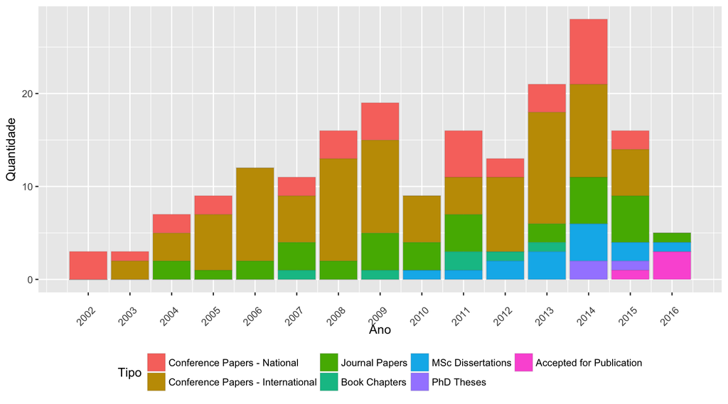

## 2016

### Artigos Aceitos para Publicação

1. Felipe Campelo, Lucas de Souza Batista, Ricardo Hiroshi Caldeira Takahashi, Henrique E. P. Diniz, Eduardo Gontijo Carrano: *Multicriteria Transformer Asset Management with Maintenance and Planning Perspectives.* IET Generation, Transmission & Distribution (Print), 2016.  
   [[DOI: 10.1049/iet-gtd.2015.1112](http://dx.doi.org/10.1049/iet-gtd.2015.1112)]
2. George Henrique Godim Fonseca, Haroldo Gambini Santos, Eduardo Gontijo Carrano: *Integrating Matheuristics and Metaheuristics for Timetabling.* Computers & Operations Research, 2016
3. Eduardo Gontijo Carrano, Gisele P. Silva, Edgard Pereira Cardoso, Ricardo Hiroshi Caldeira Takahashi: *Subpermutation Based Evolutionary Multiobjective Algorithm for Load Restoration in Power Distribution Networks.* IEEE Transactions on Evolutionary Computation, 2016

### Artigos em Periódicos

1. Felipe Campelo, Lucas de Souza Batista, Ricardo Hiroshi Caldeira Takahashi, Henrique E. P. Diniz, Eduardo Gontijo Carrano: *Multicriteria Transformer Asset Management with Maintenance and Planning Perspectives.* IET Generation, Transmission & Distribution (Print) 1(1):1-34, 2016.  
   [[DOI: 10.1049/iet-gtd.2015.1112](http://dx.doi.org/10.1049/iet-gtd.2015.1112)]

### Dissertações de Mestrado

1. Eric Wilian Lage Gonzaga: *otimização Da programação semafórica Com Base Em Modelos matemáticos* - Universidade Federal de Minas Gerais. Eduardo Gontijo Carrano (orientador principal).

Back to top

## 2015

### Artigos Aceitos para Publicação

1. George H. G. Fonseca, Haroldo G. Santos, Eduardo Gontijo Carrano: *Late Acceptance Hill-Climbing for High School Timetabling.* Journal of Scheduling, 2015.  
   [[DOI: 10.1007/s10951-015-0458-5](http://dx.doi.org/10.1007/s10951-015-0458-5)]

### Artigos em Periódicos

1. Marco T. A. Rodrigues, Mário H. G. Freitas, Flávio L. C. Pádua, Rogério M. Gomes, Eduardo Gontijo Carrano: *Evaluating Cluster Detection Algorithms and Feature Extraction Techniques in Automatic Classification of Fish Species.* Pattern Analysis and Applications 18(1):783-797, 2015.  
   [[DOI: 10.1007/s10044-013-0362-6](http://dx.doi.org/10.1007/s10044-013-0362-6)]
2. Eduardo Gontijo Carrano, Dayanne Gouveia Coelho, António Gaspar Cunha, Elizabeth Fialho Wanner, Ricardo Hiroshi Caldeira Takahashi: *Feedback-Control Operators for Improved Pareto-Set Description: Application to a Polymer Extrusion Process.* Engineering Applications of Artificial Intelligence 38(1):147-167, 2015.  
   [[DOI: 10.1016/j.engappai.2014.10.016](http://dx.doi.org/10.1016/j.engappai.2014.10.016)]
3. Fillipe Goulart, Felipe Campelo Franca Pinto: *Preference-Guided Evolutionary Algorithms for many-Objective Optimization.* Information Sciences 329(1):236-255, 2015.  
   [[DOI: 10.1016/j.ins.2015.09.015](http://dx.doi.org/10.1016/j.ins.2015.09.015)]
4. Selênio Rocha Silva, Eduardo Gontijo Carrano, Wadaed Uturbey, Manuel Losada Y Gonzalez, Márcio Melquíades Silva: *Evaluating Harmonic Voltage Distortion in Load-Variating Unbalanced Networks using Monte Carlo Simulations.* IET Generation, Transmission & Distribution (Print) 9(1):855-865, 2015.  
   [[DOI: 10.1049/iet-gtd.2014.0787](http://dx.doi.org/10.1049/iet-gtd.2014.0787)]
5. João B. Q. Zuliani, Lucas de Souza Batista, Miri Weiss Cohen, Frederico G. Guimarães: *Multi-Objective Topology Optimization with Ant Colony Optimization and Genetic Algorithms.* Computer-Aided Design and Applications (1):1-9, 2015.  
   [[DOI: 10.1080/16864360.2015.1033328](http://dx.doi.org/10.1080/16864360.2015.1033328)]

### Artigos e Resumos em Conferências Internacionais

1. Felipe Campelo Franca Pinto: *Towards Statistical Convergence Criteria for Mutation-Based Evolutionary Algorithms.* 2015 Latin America Congress on Computational Intelligence (LACCI), pp. 1-6, 2015.  
   [[DOI: 10.1109/LA-CCI.2015.7435944](http://dx.doi.org/10.1109/LA-CCI.2015.7435944)]
2. Takuya Mori, Ryo Murakami, Yuki Sato, Felipe Campelo Franca Pinto, Hajime Igarashi: *Shape Optimization of Wideband Antennas for Microwave Energy Harvesters using Fdtd.* 16th Conference on Electromagnetic Field Computation - CEFC, pp. 1-4, 2015
3. Yuki Sato, Felipe Campelo Franca Pinto, Hajime Igarashi: *Fast Shape Optimization of Antennas using Model Order Reduction.* 16th Conference on Electromagnetic Field Computation - CEFC, pp. 1-4, 2015
4. Rafael Frederico Alexandre, Felipe Campelo Franca Pinto, Carlos M. Fonseca, João António de Vasconcelos: *a Comparative Study of Algorithms for Solving the Multiobjective Open-Pit Mining Operational Planning Problems.* 8th International Conference on Evolutionary Multi-Criterion Optimization - EMO 2015, pp. 433-447, 2015
5. George Henrique Godim Fonseca, Haroldo Gambini Santos, Eduardo Gontijo Carrano: *Improving Upper Bounds in High School Timetabling by Matheuristics.* Multidisciplinary International Scheduling Conference: Theory and Applications (MISTA), , 2015

### Artigos e Resumos em Conferências Nacionais e Regionais

1. Lianny Sánchez López, Lucas de Souza Batista: *Uma estratégia De decomposição Tchebycheff Transformada Para otimização evolucionária Multiobjetivo.* Congresso Brasileiro de Inteligência Computacional (CBIC), pp. 1-6, 2015
2. Eduardo Gontijo Carrano, Eric W. L. Gonzaga, Paulo Eduardo Maciel de Almeida: *otimização Da programação semafórica Em Tempo Real Com Base Em Modelagem matemática.* Congresso Brasileiro de Inteligência Computacional (CBIC), , 2015

### Teses de Doutorado

1. Rafael Frederico Alexandre: *Despacho dinâmico De Frota De caminhões heterogênea Em Minas a céu Aberto via Algoritmos evolucionários Multiobjetivo* - Universidade Federal de Minas Gerais. Felipe Campelo Franca Pinto (co-orientador).

### Dissertações de Mestrado

1. Fernanda Caldera Takahashi: *Estudo Sobre métodos Evolutivos Multiobjetivos Voltados Para Robustez e Diversidade No espaço De decisão.* - Universidade Federal de Minas Gerais. Felipe Campelo Franca Pinto (orientador principal).
2. Douglas Chagas da Silva: *Uma Arquitetura De seleção De Redes móveis Para Ambientes heterogêneos* - Universidade Federal de Minas Gerais. Lucas de Souza Batista (orientador principal).

Back to top

## 2014

### Artigos em Periódicos

1. Eduardo Gontijo Carrano, Cristiane Geralda Taroco, Oriane Magela Neto, Ricardo Hiroshi Caldeira Takahashi: *a Multiobjective Hybrid Evolutionary Algorithm for Robust Design of Distribution Networks.* International Journal of Electrical Power & Energy Systems 63(1):645-656, 2014.  
   [[DOI: 10.1016/j.ijepes.2014.06.032](http://dx.doi.org/10.1016/j.ijepes.2014.06.032)]
2. Marconi de Arruda Pereira, Eduardo Gontijo Carrano, Clodoveu Augusto Davis Júnior, João Antônio Vasconcelos: *a Niching Genetic Programming-Based Multi-Objective Algorithm for Hybrid Data Classification.* Neurocomputing (Amsterdam) 133(1):342-357, 2014.  
   [[DOI: 10.1016/j.neucom.2013.12.048](http://dx.doi.org/10.1016/j.neucom.2013.12.048)]
3. Lucas de Souza Batista, Min Li, Felipe Campelo, Frederico G. Guimarães, David A. Lowther, Jaime A. Ramírez: *Ant Colony Optimization for the Topological Design of Interior Permanent Magnet (Ipm) Machines.* Compel (Bradford) 33(1):927-940, 2014.  
   [[DOI: 10.1108/compel-08-2013-0285](http://dx.doi.org/10.1108/compel-08-2013-0285)]
4. Flávio Vinícius Cruzeiro Martins, Eduardo Gontijo Carrano, Elizabeth Fialho Wanner, Ricardo Hiroshi Caldeira Takahashi, Geraldo Robson Mateus, Fabiola G. Nakamura: *On a Vector Space Representation in Genetic Algorithms for Sensor Scheduling in Wireless Sensor Networks.* Evolutionary Computation (Online) 22(1):361-403, 2014.  
   [[DOI: 10.1162/EVCO_a_00112](http://dx.doi.org/10.1162/EVCO_a_00112)]
5. Ulisses Cotta Cavalca, Adriano César Machada Pereira, Caio Mesquita, Eduardo Gontijo Carrano: *a Methodology for Traffic Shaping Multiobjective Optimization for Next Generation Networks.* International Journal of Computer Information Systems and Industrial Management Applications 6(1):474-483, 2014

### Artigos e Resumos em Conferências Internacionais

1. Marlon P. Lima, Thales B. Rodrigues, Rafael F. Alexandre, Ricardo H. C. Takahashi, Eduardo Gontijo Carrano: *using Evolutionary Algorithms for Channel Assignment in 802.11 Networks.* 2014 IEEE Symposium on Computational Intelligence for Communication Systems and Networks (CIComms), , 2014.  
   [[DOI: 10.1109/CICommS.2014.7014634](http://dx.doi.org/10.1109/CICommS.2014.7014634)]
2. Carlos A. S. Assis, Adriano C. M. Pereira, Marconi A. Pereira, Eduardo Gontijo Carrano: *a Genetic Programming Approach for Fraud Detection in Electronic Transactions.* 2014 IEEE Symposium on Computational Intelligence in Cyber Security (CICS), , 2014.  
   [[DOI: 10.1109/cicybs.2014.7013373](http://dx.doi.org/10.1109/cicybs.2014.7013373)]
3. Alexandre Pimenta, Frederico Gadelha Guimaraes, Eduardo Gontijo Carrano, Ciniro Aparecido Leite Nametala, Ricardo H. C. Takahashi: *Goldminer: a Genetic Programming Based Algorithm Applied to Brazilian Stock Market.* 2014 IEEE Symposium on Computational Intelligence and Data Mining (CIDM), , 2014.  
   [[DOI: 10.1109/cidm.2014.7008695](http://dx.doi.org/10.1109/cidm.2014.7008695)]
4. André Luiz Maravilha Silva, Jaime Arturo Ramírez, Felipe Campelo Franca Pinto: *Combinatorial Optimization with Differential Evolution: a Set-Based Approach.* Genetic and Evolutionary Computation Conference, pp. 69-70, 2014
5. Rodolfo Ayala Lopes, Rodrigo César Pedrosa Silva, Alan Robert Resende de Freitas, Felipe Campelo Franca Pinto, Frederico Gadelha Guimarães: *a Study on the Conﬁguration of Migratory Flows in Island Model Differential Evolution.* Genetic and Evolutionary Computation Conference, pp. 1015-1022, 2014
6. T. Mori, Yuki Sato, Ricardo Luis da Silva Adriano, Felipe Campelo Franca Pinto, Hajime Igarashi: *Optimal Design of Rf Energy Harvesting Circuit using Ga.* International Workshop on Green Solutions for Body Area Networks, , 2014
7. João B. Q. Zuliani, Miri Weiss Cohen, Lucas de Souza Batista, Frederico G. Guimarães: *Multi-Objective Topology Optimization with Ant Colony Optimization and Genetic Algorithms.* 11th International CAD Conference, pp. 1-13, 2014
8. André Costa Batista, Lucas de Souza Batista: *a Distance Based Variable Neighborhood Search for Parallel Machine Scheduling.* IEEE Symposium Series on Computational Intelligence (SSCI), pp. 1-8, 2014
9. André R. S. Vidal, Leonardo A. A. Jacobs, Lucas de Souza Batista: *An Evolutionary Approach for the Demand Side Management Optimization in Smart Grid.* IEEE Symposium Series on Computational Intelligence (SSCI), pp. 1-7, 2014
10. Douglas Chagas da Silva, Claudio de Castro Monteiro, Lucas de Souza Batista: *classificação e seleção De Redes via Tomada De decisão multicritério.* VI Congreso Internacional de Computación y Telecomunicaciones (COMTEL), pp. 258-264, 2014

### Artigos e Resumos em Conferências Nacionais e Regionais

1. Fernanda Caldeira Takahashi, Ricardo Hiroshi Caldeira Takahashi, Felipe Campelo Franca Pinto: *Algoritmo genético Multiobjetivo Com Medida De Aglomeracao No Espaco De Variaveis De Decisao.* Congresso Brasileiro de Automática, pp. 2485-2492, 2014
2. Rafael Frederico Alexandre, João Batista Mendes, Felipe Campelo Franca Pinto, João António de Vasconcelos: *Simmim: Uma Ferramenta Para simulação, otimização e auxílio à Tomada De decisões Em Ambientes De Minas a céu Aberto..* XLVI Simpósio Brasileiro de Pesquisa Operacional (SBPO), pp. 1740-1751, 2014
3. André R. S. Vidal, Lucas de Souza Batista: *otimização Evolutiva Do Gerenciamento Pelo Lado Da Demanda Em Smart Grid.* XX Congresso Brasileiro de Automática (CBA), pp. 1-8, 2014
4. André Costa Batista, Lucas de Souza Batista: *síntese De Uma Estrutura De vizinhança e Operadores Evolutivos Para o Escalonamento De máquinas.* XX Congresso Brasileiro de Automática (CBA), pp. 1-8, 2014
5. Lucas de Souza Batista, Marcos Vinicius Bortolus, Guilherme Ximenes Coutinho Dias, Leísa Ferreira Amaral Gomes, Sanderson Nascimento Soares, Débora Matoso Costa, Kaio Adriano Batista Fidelis: *Selex - Projeto De extensão Em Engenharia De Sistemas / Ufmg.* Congresso Brasileiro de Ensino de Engenharia (COBENGE), pp. 1-11, 2014
6. Carlos A. S. Assis, Adriano César Machada Pereira, Marconi de Arruda Pereira, Eduardo Gontijo Carrano: *técnicas De programação genética Para Descoberta De Fraudes Em transações De comércio eletrônico.* Symposium on Knowledge Discovery, Mining and Learning, , 2014
7. Gisele P. Silva, Nery W. C. Filho, Ricardo Hiroshi Caldeira Takahashi, Edgard Pereira Cardoso, Mauro O. Prates, Eduardo Gontijo Carrano: *restauração De Redes De Energia Utilizando Algoritmos genéticos Multiobjetivo.* Congresso Brasileiro de Automática, , 2014

### Teses de Doutorado

1. Thaís de Fátima Araújo: *Uma Proposta De Despacho estocástico Para Sistemas elétricos De distribuição Com geração Fotovoltaica* - Universidade Federal de Minas Gerais. Lucas de Souza Batista (co-orientador).
2. Cristiane Geralda Tarôco: *Planejamento Integrado De Sistemas De distribuição De Energia elétrica Robustos Com geração distribuída* - Universidade Federal de Minas Gerais. Eduardo Gontijo Carrano (orientador principal).

### Dissertações de Mestrado

1. Andre Luiz Maravilha Silva: *Algoritmo Baseado Em evolução Diferencial Para solução De Problemas De otimização combinatória* - Universidade Federal de Minas Gerais. Felipe Campelo Franca Pinto (orientador principal).
2. Fillipe Goulart Silva Mendes: *Preference-Guided Evolutionary Algorithms for Optimization with many Objectives* - Universidade Federal de Minas Gerais. Felipe Campelo Franca Pinto (orientador principal).
3. Cesar Augusto de Oliveira Soares: *Algoritmos Coevolutivos Baseados Em Teoria De Jogos* - Universidade Federal de Minas Gerais. Felipe Campelo Franca Pinto (orientador principal).
4. Gisele Pinheiro da Silva: *restauração De Redes De Energia Utilizando Algoritmos genéticos Multiobjetivo* - Universidade Federal de Minas Gerais. Eduardo Gontijo Carrano (orientador principal).

Back to top

## 2013

### Artigos em Periódicos

1. Luciana Assis, André Luiz Maravilha Silva, Felipe Campelo Franca Pinto, Alessandro Vivas, Jaime Arturo Ramírez: *Multiobjective Vehicle Routing Problem with Fixed Delivery and Optional Collections.* Optimization Letters (Print) 7(1):1419-1431, 2013.  
   [[DOI: 10.1007/s11590-012-0551-z](http://dx.doi.org/10.1007/s11590-012-0551-z)]
2. Alan Robert Resende de Freitas, Victor Miranda Rangel Silva, Felipe Campelo Franca Pinto, Frederico Gadelha Guimarães: *Optimizing Two-Level Reverse Distribution Networks with Hybrid Memetic Algorithms.* Optimization Letters (Print) 7(1), 2013.  
   [[DOI: 10.1007/s11590-013-0615-8](http://dx.doi.org/10.1007/s11590-013-0615-8)]

### Artigos e Resumos em Conferências Internacionais

1. Andre L. Maravilha, Jaime A. Ramirez, Felipe Campelo Franca Pinto: *a New Algorithm Based on Differential Evolution for Combinatorial Optimization.* 2013 BRICS Congress on Computational Intelligence & 11th Brazilian Congress on Computational Intelligence (BRICSCCI & CBIC), pp. 60-66, 2013.  
   [[DOI: 10.1109/brics-cci-cbic.2013.21](http://dx.doi.org/10.1109/brics-cci-cbic.2013.21)]
2. Cesar A.O. Soares, Lucas S. Batista, Felipe Campelo Franca Pinto, Frederico G. Guimaraes: *Computation of Mixed Strategy Non-Dominated Nash Equilibria in Game Theory.* 2013 BRICS Congress on Computational Intelligence & 11th Brazilian Congress on Computational Intelligence (BRICSCCI & CBIC), pp. 242-247, 2013.  
   [[DOI: 10.1109/brics-cci-cbic.2013.47](http://dx.doi.org/10.1109/brics-cci-cbic.2013.47)]
3. Alhandra C. M. A. Tepedino, Ricardo Hiroshi Caldeira Takahashi, Eduardo Gontijo Carrano: *Distance Based Nsga-Ii for Earliness and Tardiness Minimization in Parallel Machine Scheduling.* 2013 IEEE Congress on Evolutionary Computation (CEC), , 2013.  
   [[DOI: 10.1109/CEC.2013.6557586](http://dx.doi.org/10.1109/CEC.2013.6557586)]
4. Ulisses Cotta Cavalca, Caio Mesquita, Adriano César Machada Pereira, Eduardo Gontijo Carrano: *a Computational Intelligence Based Approach for Computer Network Traffic Shaping.* 2013 IEEE Congress on Evolutionary Computation (CEC), , 2013.  
   [[DOI: 10.1109/CEC.2013.6557893](http://dx.doi.org/10.1109/CEC.2013.6557893)]
5. Cesar A. O. Soares, Felipe Campelo Franca Pinto, Frederico Gadelha Guimarães: *a Multiobjective Formulation for Computing Mixed Strategy Nash Equilibria.* EVOLVE 2013, pp. 31-36, 2013
6. André Luis Silva, J.A. Ramirez, Felipe Campelo Franca Pinto: *a Statistical Study of Discrete Differential Evolution Approaches for the Capacitated Vehicle Routing Problem.* Genetic and Evolutionary Computation Conference - GECCO 2013, , 2013
7. Fillipe Goulart, Lucas S. Batista, Felipe Campelo Franca Pinto: *Influence of Relaxed Dominance Criteria in Multiobjective Evolutionary Algorithms.* Genetic and Evolutionary Computation Conference - GECCO 2013, , 2013
8. Rodolfo Ayala Lopes, Rodrigo César Pedrosa Silva, Felipe Campelo Franca Pinto, Frederico Gadelha Guimarães: *Dynamic Selection of Migration Flows in Island Model Differential Evolution.* Genetic and Evolutionary Computation Conference - GECCO 2013, , 2013
9. Yuki Sato, Felipe Campelo Franca Pinto, Hajime Igarashi: *Meander Line Antenna Design using an Adaptive Genetic Algorithm.* 15th Conference on Electromagnetic Field Computation - CEFC, pp. 1889-1892, 2013
10. João B. Q. Zuliani, Lucas de Souza Batista, Frederico G. Guimarães, Miri Weiss Cohen, Min Li, David A. Lowther: *Multiobjective Topology Optimization with Ant Colony Systems in Applied Electromagnetics.* The 17th International Conference on the Computation of Electromagnetic Fields (Compumag), pp. 1-2, 2013
11. Fabiano T. Novais, Lucas de Souza Batista, Agnaldo J. Rocha, Frederico G. Guimarães: *a Multiobjective Estimation of Distribution Algorithm Based on Artificial Bee Colony.* 1st BRICS Countries Congress on Computational Intelligence, , 2013
12. Breno C. Costa, Paulo Eduardo Maciel de Almeida, Eduardo Gontijo Carrano, Bruno L. A. Alberto: *Fixed Time Traffic Signal Optimization in Urban Networks using a Simulation-Based Multiobjective Algorithm.* World Congress on Transport Research, , 2013

### Artigos e Resumos em Conferências Nacionais e Regionais

1. Ulisses Cotta Cavalca, Caio Mesquita, Adriano César Machada Pereira, Eduardo Gontijo Carrano: *Metodologia Baseada Em inteligência Computacional Para otimização De Qualidade De serviço Em Links Internet.* Workshop em Desempenho de Sistemas Computacionais e de Comunicação, , 2013
2. T. L. Alcântra, Marlon Paolo Lima, R. F. Alexandre, Eduardo Gontijo Carrano, Ricardo Hiroshi Caldeira Takahashi: *alocação De Canais Em Redes Wlan Utilizando Algoritmo genético.* Simpósio Brasileiro de Pesquisa Operacional, , 2013
3. Carlos A. S. Assis, Adriano César Machada Pereira, Marconi de Arruda Pereira, Eduardo Gontijo Carrano: *Uso De técnicas De programação genética Para detecção De Fraudes Em transações eletrônicas.* Brazilian Symposium on Multimedia and the Web, , 2013

### Capítulos de Livros

1. Luciana Pereira de Assis, André Luiz Maravilha Silva, Felipe Campelo Franca Pinto, Alessandro Vivas Andrade, Jaime Arturo Ramírez: *Problema De Roteamento De veículos Multiobjetivo Com Coleta Seletiva.* In: Meta-heurísticas Em Pesquisa Operacional, vol. 1. pp. 181-202, 2013.  
   [[DOI: 10.7436/2013.mhpo.12](http://dx.doi.org/10.7436/2013.mhpo.12)]

### Dissertações de Mestrado

1. Rodolfo Ayala Lopes Costa: *Topologias dinâmicas Para Modelo Em Ilhas Usando evolução Diferencial* - Universidade Federal de Minas Gerais. Felipe Campelo Franca Pinto (co-orientador).
2. Ulisses Cotta Cavalca: *Metodologia Baseada Em inteligência Computacional Para otimização De Traffic Shaping Em Links De Redes De Computadores* - Centro Federal de Educação Tecnológica de Minas Gerais. Eduardo Gontijo Carrano (co-orientador).
3. Danilo Ribeiro Gomes: *otimização Multiobjetivo Para a alocação De Chaves Em Redes De distribuição De Energia elétrica* - Universidade Federal de Minas Gerais. Eduardo Gontijo Carrano (orientador principal).

Back to top

## 2012

### Artigos e Resumos em Conferências Internacionais

1. Ulisses Cotta Cavalca, Caio Mesquita, Adriano César Machada Pereira, Eduardo Gontijo Carrano: *a Methodology for Traffic Shaping Multiobjective Optimization for Next Generation Network.* 2012 Fourth International Conference on Computational Aspects of Social Networks (CASoN), , 2012.  
   [[DOI: 10.1109/CASoN.2012.6412426](http://dx.doi.org/10.1109/CASoN.2012.6412426)]
2. Marlon Paolo Lima, Eduardo Gontijo Carrano, Ricardo Hiroshi Caldeira Takahashi: *Multiobjective Planning of Wireless Local Area Networks (Wlan) using Genetic Algorithms.* IEEE World Congress on Computational Intelligence - IEEE WCCI, , 2012.  
   [[DOI: 10.1109/CEC.2012.6253000](http://dx.doi.org/10.1109/CEC.2012.6253000)]
3. Dayanne Gouveia Coelho, Elizabeth Fialho Wanner, Sérgio Ricardo de Souza, Eduardo Gontijo Carrano, Robin C Purshouse: *a Multiobjective Evolutionary Algorithm for the 2d Guillotine Strip Packing Problem.* IEEE World Congress on Computational Intelligence - IEEE WCCI, , 2012.  
   [[DOI: 10.1109/CEC.2012.6256469](http://dx.doi.org/10.1109/CEC.2012.6256469)]
4. Cristiane Geralda Taroco, Eduardo Gontijo Carrano, Oriane Magela Neto, Ricardo Hiroshi Caldeira Takahashi: *a Faster Genetic Algorithm for Substation Location and Network Design of Power Distribution Systems.* IEEE World Congress on Computational Intelligence - IEEE WCCI, , 2012.  
   [[DOI: 10.1109/CEC.2012.6256532](http://dx.doi.org/10.1109/CEC.2012.6256532)]
5. Sanderson Vanucci, Rafael Bicalho, Eduardo Gontijo Carrano, Ricardo Hiroshi Caldeira Takahashi: *a Modified Nsga-Ii for the Multiobjective Multi-Mode Resource-Constrained Project Scheduling Problem.* IEEE World Congress on Computational Intelligence - IEEE WCCI, , 2012.  
   [[DOI: 10.1109/CEC.2012.6256616](http://dx.doi.org/10.1109/CEC.2012.6256616)]
6. Alan Robert Resende de Freitas, Victor M. R. Silva, Felipe Campelo Franca Pinto, Frederico Gadelha Guimarães: *Genetic Algorithms Applied to Reverse Distribution Networks.* 7th International Conference on Soft Computing Models in Industrial and Environmental Applications, pp. 317-326, 2012
7. Rodolfo Ayala Lopes, Rodrigo César Pedrosa Silva, Felipe Campelo Franca Pinto, F.G. Guimaraes: *a Multi-Agent Approach to the Adaptation of Migration Topology in Island Model Evolutionary Algorithms.* Brazilian Simposium on Neural Networks, pp. 160-165, 2012
8. Lucas de Souza Batista, Min Li, Felipe Campelo, Frederico G. Guimarães, David A. Lowther, Jaime A. Ramírez: *Ant Colony Optimization for the Topology Design of Ipm Machines.* The 12th International Workshop on Optimization and Inverse Problems in Electromagnetism (OIPE), pp. 1-2, 2012

### Artigos e Resumos em Conferências Nacionais e Regionais

1. Ulisses Cotta Cavalca, Adriano César Machada Pereira, Caio Mesquita, Eduardo Gontijo Carrano: *Uma Metodologia Para otimização Multiobjetivo De Modelagem De tráfego Para Sistemas Internet.* XV Encontro de Modelagem Computacional, , 2012
2. Danilo Ribeiro Gomes, Oriane Magela Neto, Eduardo Gontijo Carrano, André Rodrigues Cruz: *Planejamento Integrado Da reconfiguração De Redes De distribuição De Energia elétrica.* Congresso Brasileiro de Automática - CBA 2012, , 2012

### Capítulos de Livros

1. Eduardo Gontijo Carrano: *distâncias Generalizadas: espaços combinatórios.* In: Manual De computação Evolutiva e metaheurística, vol. 1. pp. 249-274, 2012

### Dissertações de Mestrado

1. Breno Carvalho Costa: *programação semafórica De Tempo Fixo Em microregiões Utilizando otimização Multiobjetivo e simulação microscópica* - Centro Federal de Educação Tecnológica de Minas Gerais. Eduardo Gontijo Carrano (co-orientador).
2. Alhandra Cristina Moraes Antunes Tepedino: *Desenvolvimento De Algoritmos genéticos Baseados Em distância Para solução De Variantes Mono e Multiobjetivo Do Problema De Escalonamento De máquinas Paralelas* - Centro Federal de Educação Tecnológica de Minas Gerais. Eduardo Gontijo Carrano (orientador principal).

Back to top

## 2011

### Artigos em Periódicos

1. Bruno Baeta Souza, Eduardo Gontijo Carrano, Oriane Magela Neto, Ricardo Hiroshi Caldeira Takahashi: *Immune System Memetic Algorithm for Power Distribution Network Design with Load Evolution Uncertainty.* Electric Power Systems Research (Print) 81(1):527-537, 2011.  
   [[DOI: 10.1016/j.epsr.2010.10.011](http://dx.doi.org/10.1016/j.epsr.2010.10.011)]
2. Lucas S. Batista, Felipe Campelo, Frederico G. Guimarães, Jaime A. Ramírez: *Multi-Domain Topology Optimization with Ant Colony Systems.* Compel (Bradford) 30(1):1792-1803, 2011.  
   [[DOI: 10.1108/03321641111168101](http://dx.doi.org/10.1108/03321641111168101)]
3. Flávio Vinícius Cruzeiro Martins, Eduardo Gontijo Carrano, Elizabeth Fialho Wanner, Ricardo Hiroshi Caldeira Takahashi, Geraldo Robson Mateus: *a Hybrid Multiobjective Evolutionary Approach for Improving the Performance of Wireless Sensor Networks.* IEEE Sensors Journal 11(1):545-554, 2011.  
   [[DOI: 10.1109/JSEN.2010.2048897](http://dx.doi.org/10.1109/JSEN.2010.2048897)]
4. Eduardo Gontijo Carrano, Elizabeth Fialho Wanner, Ricardo Hiroshi Caldeira Takahashi: *a Multi-Criteria Statistical Based Comparison Methodology for Evaluating Evolutionary Algorithms.* IEEE Transactions on Evolutionary Computation 15(1):848-870, 2011.  
   [[DOI: 10.1109/TEVC.2010.2069567](http://dx.doi.org/10.1109/TEVC.2010.2069567)]

### Artigos e Resumos em Conferências Internacionais

1. Lucas S. Batista, Felipe Campelo Franca Pinto, Frederico Gadelha Guimarães, Jaime Arturo Ramírez: *Pareto Cone-Epsilon Dominance: Improving Convergence and Diversity in Multiobjective Evolutionary Algorithms.* 6th International Conference on Evolutionary Multiobjective Optimization, pp. 76-90, 2011
2. Lucas S. Batista, Felipe Campelo Franca Pinto, Frederico Gadelha Guimarães, Jaime Arturo Ramírez: *a Comparison of Dominance Criteria in many-Objective Optimization Problems.* IEEE Congress on Evolutionary Computation, pp. 2359-2366, 2011
3. Lucas de Souza Batista, Felipe Campelo, Frederico G. Guimarães, Jaime A. Ramírez: *Pareto Cone Epsilon-Dominance: Improving Convergence and Diversity in Multiobjective Evolutionary Algorithms.* The Sixth International Conference on Evolutionary Multi-Criterion Optimization (EMO), pp. 76-90, 2011
4. Dayanne Gouveia Coelho, Marcellus Xavier Oliveira, Elizabeth Fialho Wanner, Sérgio Ricardo de Souza, Marcone Jamilson Freitas Souza, Eduardo Gontijo Carrano: *An Application Multiobjective for Open Dimensional Problem Guillotined.* Iberian Latin-American Congress on Computational Methods in Engineering, , 2011

### Artigos e Resumos em Conferências Nacionais e Regionais

1. Fillipe Goulart, Felipe Campelo Franca Pinto, Jaime Arturo Ramírez: *Estudo Dos Mecanismos De Funcionamento Do Algoritmo De evolução Diferencial.* X Congresso Brasileiro de Inteligência Computacional, , 2011
2. Subtil Robert F, Eduardo Gontijo Carrano, Ricardo Hiroshi Caldeira Takahashi, Marcone Jamilson Freitas Souza, Sérgio Ricardo de Souza: *Improved Genetic Operators for the Multiobjective Generalized Assignment Problem.* Congresso da Sociedade Brasileira de Computação, , 2011
3. Cristiane Geralda Taroco, Eduardo Gontijo Carrano, Oriane Magela Neto: *Projeto Multiobjetvo De Redes De distribuição De Energia elétrica Com Incertezas Na evolução Da Carga Utilizando Algoritmos De Busca Local.* Simpósio Brasileiro de Automação Inteligente, , 2011
4. Marlon Paolo Lima, Eduardo Gontijo Carrano, Ricardo Hiroshi Caldeira Takahashi: *Planejamento multicritério De Redes Wlan Utilizando Algoritmos genéticos.* Simpósio Brasileiro de Pesquisa Operacional, , 2011
5. Rafael Bicalho, Eduardo Gontijo Carrano, Ricardo Hiroshi Caldeira Takahashi: *Usando Nsga-Ii No Problema Generalizado De atribuição Multiobjetivo Com precedência.* Simpósio Brasileiro de Pesquisa Operacional, , 2011

### Capítulos de Livros

1. Eduardo Gontijo Carrano, Lívia Alves Moreira, Ricardo Hiroshi Caldeira Takahashi: *a New Memory Based Variable-Length Encoding Genetic Algorithm for Multiobjective Optimization.* In: Lecture Notes in Computer Science, vol. 65766576. pp. 328-342, 2011.  
   [[DOI: 10.1007/978-3-642-19893-9_23](http://dx.doi.org/10.1007/978-3-642-19893-9_23)]
2. Ricardo Hiroshi Caldeira Takahashi, Eduardo Gontijo Carrano, Elizabeth Fialho Wanner: *On a Stochastic Differential Equation Approach for Multiobjective Optimization Up to Pareto-Criticality.* In: Lecture Notes in Computer Science, vol. 65766576. pp. 61-75, 2011.  
   [[DOI: 10.1007/978-3-642-19893-9_5](http://dx.doi.org/10.1007/978-3-642-19893-9_5)]

### Dissertações de Mestrado

1. Marlon Paolo Lima: *Planejamento Multiobjetivo De Redes Wlan Utilizando Algoritmos genéticos* - Universidade Federal de Minas Gerais. Eduardo Gontijo Carrano (orientador principal).

Back to top

## 2010

### Artigos em Periódicos

1. Eduardo Gontijo Carrano, Ricardo Hiroshi Caldeira Takahashi, Carlos M. Fonseca, Oriane Magela Neto: *Non-Linear Network Optimization - An Embedding Vector Space Approach.* IEEE Transactions on Evolutionary Computation 14(1):206-226, 2010.  
   [[DOI: 10.1109/TEVC.2009.2028330](http://dx.doi.org/10.1109/TEVC.2009.2028330)]
2. Lucas de Souza Batista, Diogo B. Oliveira, Frederico Gadelha Guimarães, Elson J. Silva, Jaime Arturo Ramírez: *Dynamic Multiobjective Clonal Selection Algorithm for Engineering Design.* IEEE Transactions on Magnetics 46(1):3033-3036, 2010.  
   [[DOI: 10.1109/TMAG.2010.2044144](http://dx.doi.org/10.1109/TMAG.2010.2044144)]
3. Cristiane Geralda Taroco, Eduardo Gontijo Carrano, Oriane Magela Neto, Ricardo Hiroshi Caldeira Takahashi: *Robust Design of Power Distribution Systems using an Enhanced Multiobjective Genetic Algorithm.* International Journal of Natural Computing Research 1(1):92-112, 2010.  
   [[DOI: 10.4018/jncr.2010040106](http://dx.doi.org/10.4018/jncr.2010040106)]

### Artigos e Resumos em Conferências Internacionais

1. Subtil Robert F, Eduardo Gontijo Carrano, Marcone Jamilson Freitas Souza, Ricardo Hiroshi Caldeira Takahashi: *using an Enhanced Integer Nsga-Ii for Solving the Multiobjective Generalized Assignment Problem.* World Congress on Computational Intelligence, , 2010.  
   [[DOI: 10.1109/CEC.2010.5586086](http://dx.doi.org/10.1109/CEC.2010.5586086)]
2. Lucas de Souza Batista, Felipe Campelo, Frederico Gadelha Guimarães, Jaime Arturo Ramírez: *a New Self-Adaptive Approach for Evolutionary Multiobjective Optimization.* IEEE Congress on Evolutionary Computation (CEC), pp. 1-8, 2010.  
   [[DOI: 10.1109/CEC.2010.5586512](http://dx.doi.org/10.1109/CEC.2010.5586512)]
3. Flávio Vinícius Cruzeiro Martins, Eduardo Gontijo Carrano, Elizabeth Fialho Wanner, Ricardo Hiroshi Caldeira Takahashi, Geraldo Robson Mateus: *An Evolutionary Dynamic Approach for Designing Wireless Sensor Networks for Real Time Monitoring.* IEEE / ACM International Symposium on Distributed Simulation and Real Time Applications, , 2010.  
   [[DOI: 10.1109/DS-RT.2010.25](http://dx.doi.org/10.1109/DS-RT.2010.25)]
4. Lucas S. Batista, Felipe Campelo Franca Pinto, Frederico Gadelha Guimarães, Jaime Arturo Ramírez: *Multi-Domain Topology Optimization with Ant Colony Systems.* 14th International IGTE Symposium on Numerical Field Calculation in Electrical Engineering, pp. 1-6, 2010
5. Kota Watanabe, Felipe Campelo Franca Pinto, Yosuke Iijima, K. Kawano, T. Matsuo, T. Mifune, Hajime Igarashi: *Optimization of Inductors using Evolutionary Algorithms and Its Experimental Validation.* 17th Conference on the Computation of Electromagnetic Fields - COMPUMAG, pp. 3393-3396, 2010

### Dissertações de Mestrado

1. Cristiane Geralda Tarôco: *Projeto multicritério De Sistemas De distribuição De Energia elétrica Sob Contextos Incertos Utilizando Algoritmos De Busca Local* - Universidade Federal de Minas Gerais. Eduardo Gontijo Carrano (co-orientador).

Back to top

## 2009

### Artigos em Periódicos

1. Lucas de Souza Batista, Frederico G. Guimarães, Jaime A. Ramírez: *New Operators for Multi-Objective Clonal Selection Algorithms.* Compel (Bradford) 28(1):833-850, 2009.  
   [[DOI: 10.1108/03321640910958955](http://dx.doi.org/10.1108/03321640910958955)]
2. Lucas de Souza Batista, Frederico G. Guimarães, Jaime A. Ramírez: *a Distributed Clonal Selection Algorithm for Optimization in Electromagnetics.* IEEE Transactions on Magnetics 45(1):1598-1601, 2009.  
   [[DOI: 10.1109/TMAG.2009.2012752](http://dx.doi.org/10.1109/TMAG.2009.2012752)]
3. Felipe Campelo Franca Pinto, Frederico Gadelha Guimarães, Jaime Arturo Ramírez: *using Self-Organizing Maps as a Decision-Making Tool for Multiobjective Design in Engineering.* Learning and Nonlinear Models 7(1):65-70, 2009
4. Lucas de Souza Batista, Frederico Gadelha Guimarães, Prakash Paul, Jaime Arturo Ramírez: *Optimization of Electromagnetic Devices using Artiﬁcial Immune Systems.* Journal of Microwaves and Optoelectronics 8(1):154-162, 2009

### Artigos e Resumos em Conferências Internacionais

1. Jésus J. S. Santos, Diogo B. Oliveira, Elizabeth Fialho Wanner, Eduardo Gontijo Carrano, Ricardo Hiroshi Caldeira Takahashi, Elson José da Silva, Oriane Magela Neto: *Designing a Multilayer Microwave Heating Device using a Multiobjective Genetic Algorithm.* IEEE Congress on Evolutionary Computation - CEC’09, pp. 911-917, 2009.  
   [[DOI: 10.1109/CEC.2009.4983042](http://dx.doi.org/10.1109/CEC.2009.4983042)]
2. Lucas de Souza Batista, Frederico G. Guimarães, Jaime A. Ramírez: *a Differential Mutation Operator for the Archive Population of Multi-Objective Evolutionary Algorithms.* IEEE Congress on Evolutionary Computation (CEC), pp. 1108-1115, 2009.  
   [[DOI: 10.1109/CEC.2009.4983070](http://dx.doi.org/10.1109/CEC.2009.4983070)]
3. Flávio Vinícius Cruzeiro Martins, Eduardo Gontijo Carrano, Elizabeth Fialho Wanner, Ricardo Hiroshi Caldeira Takahashi, Geraldo Robson Mateus: *a Dynamic Multiobjective Hybrid Approach for Designing Wireless Sensor Networks.* IEEE Congress on Evolutionary Computation - CEC’09, pp. 1145-1152, 2009.  
   [[DOI: 10.1109/CEC.2009.4983075](http://dx.doi.org/10.1109/CEC.2009.4983075)]
4. Tiago Lima Pereira, Eduardo Gontijo Carrano, Ricardo Hiroshi Caldeira Takahashi, Elizabeth Fialho Wanner, Oriane Magela Neto: *Continuous-Space Embedding Genetic Algorithm Applied to the Degree Constrained Minimum Spanning Tree Problem.* IEEE Congress on Evolutionary Computation - CEC’09, pp. 1391-1398, 2009.  
   [[DOI: 10.1109/CEC.2009.4983106](http://dx.doi.org/10.1109/CEC.2009.4983106)]
5. Cidiney Silva, Jésus J. S. Santos, Elizabeth Fialho Wanner, Eduardo Gontijo Carrano, Ricardo Hiroshi Caldeira Takahashi: *Semi-Supervised Training of Least Squares Support Vector Machine using a Multiobjective Evolutionary Algorithm.* IEEE Congress on Evolutionary Computation - CEC’09, pp. 2996-3002, 2009.  
   [[DOI: 10.1109/CEC.2009.4983321](http://dx.doi.org/10.1109/CEC.2009.4983321)]
6. Flávio Vinícius Cruzeiro Martins, Eduardo Gontijo Carrano, Elizabeth Fialho Wanner, Ricardo Hiroshi Caldeira Takahashi, Geraldo Robson Mateus: *a Hybrid Multiobjective Approach for Designing Wireless Sensor Networks.* ACM International Conference on Modeling, Analysis and Simulation of Wireless and Mobile Systems - MSWiN’09, , 2009.  
   [[DOI: 10.1145/1641804.1641858](http://dx.doi.org/10.1145/1641804.1641858)]
7. Felipe Campelo Franca Pinto, Jaime Arturo Ramírez, Hajime Igarashi: *Design of Conventional c-Core Magnets using a Multi-Step Optimization Procedure.* XVII Compumag - Conference on the Computation of Electromagnetic Fields, pp. 410-411, 2009
8. Felipe Campelo Franca Pinto, Frederico Gadelha Guimarães, J.A. Ramirez, Hajime Igarashi: *Hybrid Estimation of Distribution Algorithm using Local Function Approximations.* 13th Conference on Electromagnetic Field Computation - CEFC, pp. 1558-1561, 2009
9. Lucas de Souza Batista, Diogo B. Oliveira, Frederico G. Guimarães, Elson J. Silva, Jaime A. Ramírez: *Dynamic Multiobjective Clonal Selection Algorithm for Engineering Design.* The 17th International Conference on the Computation of Electromagnetic Fields (Compumag), pp. 295-296, 2009
10. Lucas de Souza Batista, Alan R. R. de Freitas, Frederico G. Guimarães, Jaime A. Ramírez: *Grasp e Redes Neurais Auto-organizáveis: Uma Meta-heurística Para a solução Do Tsp.* 1a Escola Luso-Brasileira de Computação Evolutiva (ELBCE), , 2009

### Artigos e Resumos em Conferências Nacionais e Regionais

1. Felipe Campelo Franca Pinto, Frederico Gadelha Guimarães, Jaime Arturo Ramírez: *using Self-Organizing Maps as a Decision-Making Tool for Multiobjective Design in Engineering.* Congresso Brasileiro de Redes Neurais, , 2009
2. Lucas de Souza Batista, Alan R. R. de Freitas, Frederico G. Guimarães, Jaime A. Ramírez: *Resolvendo o Problema Do Caixeiro Viajante via Procedimento De Busca Adaptativa aleatória Gulosa Com construção Baseada Em Redes Neurais Auto-organizáveis.* Congresso Brasileiro de Redes Neurais e Inteligência Computacional (IX CBRN/IC), , 2009
3. Elizabeth Fialho Wanner, Gladston J. P. Moreira, Eduardo Gontijo Carrano, Ricardo Hiroshi Caldeira Takahashi, Luiz Henrique Duczmal: *Multiobjective Training of Rbf Networks for Large Data Sets with Lmi?s.* Congresso Brasileiro de Redes Neurais, , 2009
4. Fábio Pires Mourão, Sérgio Ricardo de Souza, Eduardo Gontijo Carrano, Marcone Jamilson Freitas Souza: *Um Algoritmo Evolutivo Multiobjetivo Em Duas Fases Aplicado Ao Problema De Fluxo Multiproduto binário Com Balanceamento Da Rede.* Congresso Nacional de Matemática Aplicada e Computacional, , 2009

### Capítulos de Livros

1. Ricardo Hiroshi Caldeira Takahashi, Frederico Gadelha Guimaraes, Elizabeth Fialho Wanner, Eduardo Gontijo Carrano: *Feedback-Control Operators for Evolutionary Multiobjective Optimization.* In: Lecture Notes in Computer Science, vol. 5467. pp. 66-80, 2009.  
   [[DOI: 10.1007/978-3-642-01020-0_10](http://dx.doi.org/10.1007/978-3-642-01020-0_10)]

Back to top

## 2008

### Artigos em Periódicos

1. Eduardo Gontijo Carrano, Rodrigo Tomás Nogueira Cardoso, Ricardo Hiroshi Caldeira Takahashi, Carlos M. Fonseca, Oriane Magela Neto: *Power Distribution Network Expansion Scheduling using Dynamic Programming Genetic Algorithm.* IET Generation, Transmission & Distribution (Print) 2(1):444-455, 2008.  
   [[DOI: 10.1049/iet-gtd:20070174](http://dx.doi.org/10.1049/iet-gtd:20070174)]
2. Felipe Campelo Franca Pinto, Kota Watanabe, Hajime Igarashi: *Topology Optimization with Smoothness Considerations.* International Journal of Applied Electromagnetics and Mechanics 28(1):187-192, 2008

### Artigos e Resumos em Conferências Internacionais

1. Eduardo Gontijo Carrano, Bruno Baeta Souza, Oriane Magela Neto, Ricardo Hiroshi Caldeira Takahashi: *An Immune Inspired Memetic Algorithm for Power Distribution System Design under Load Evolution Uncertainties.* IEEE World Congress on Computational Intelligence - WCCI’08, , 2008.  
   [[DOI: 10.1109/CEC.2008.4631238](http://dx.doi.org/10.1109/CEC.2008.4631238)]
2. Eduardo Gontijo Carrano, Ricardo Hiroshi Caldeira Takahashi, Walmir Matos Caminhas, Oriane Magela Neto: *a Genetic Algorithm for Multiobjective Training of Anfis Fuzzy Networks.* IEEE World Congress on Computational Intelligence - WCCI’08, , 2008.  
   [[DOI: 10.1109/CEC.2008.4631239](http://dx.doi.org/10.1109/CEC.2008.4631239)]
3. Eduardo Gontijo Carrano, Ricardo Hiroshi Caldeira Takahashi, Elizabeth Fialho Wanner: *An Enhanced Statistical Approach for Evolutionary Algorithm Comparison.* Genetic and Evolutionary Computation Conference - GECCO’08, , 2008.  
   [[DOI: 10.1145/1389095.1389270](http://dx.doi.org/10.1145/1389095.1389270)]
4. Flávio Vinícius Cruzeiro Martins, Eduardo Gontijo Carrano, Elizabeth Fialho Wanner, Ricardo Hiroshi Caldeira Takahashi: *The Micro-Genetic Operator in the Search of Global Trends.* Genetic and Evolutionary Computation Conference - GECCO’08, , 2008.  
   [[DOI: 10.1145/1389095.1389310](http://dx.doi.org/10.1145/1389095.1389310)]
5. Elizabeth Fialho Wanner, Eduardo Gontijo Carrano, Ricardo Hiroshi Caldeira Takahashi: *Coordinate Change-Based Operator for Genetic Algorithms.* Genetic and Evolutionary Computation Conference - GECCO’08, , 2008.  
   [[DOI: 10.1145/1389095.1389322](http://dx.doi.org/10.1145/1389095.1389322)]
6. Felipe Campelo Franca Pinto, Kota Watanabe, Hajime Igarashi: *a Spectral Topology Optimization Approach to the Design of Magnetic Devices.* 13th Biennial IEEE Conference on Electromagnetic Fields Computation (CEFC), pp. 340-340, 2008
7. Felipe Campelo Franca Pinto, Frederico Gadelha Guimarães, Jaime Arturo Ramírez, Hajime Igarashi: *Optimization in Electromagnetics using the Real-Coded Clonal Selection Algorithm.* IEEE Conference on Soft Computing in Industrial Applications, pp. 89-94, 2008
8. Felipe Campelo Franca Pinto, Satoshi Ota, Kota Watanabe, Hajime Igarashi: *Generating Parametric Design Models using Information from Topology Optimization.* 16th Conference on the Computation of Electromagnetic Fields - COMPUMAG, , 2008
9. Felipe Campelo Franca Pinto, Frederico Gadelha Guimarães, Hajime Igarashi: *Multiobjective Optimization using Compromise Programming and an Immune Algorithm.* 16th Conference on the Computation of Electromagnetic Fields - COMPUMAG, pp. 982-985, 2008
10. Lucas de Souza Batista, Frederico G. Guimarães, Jaime A. Ramírez: *a Distributed Clonal Selection Algorithm for Optimization in Electromagnetics.* 13th Biennial IEEE Conference on Electromagnetic Field Computation, pp. 210-210, 2008
11. Lucas de Souza Batista, Frederico G. Guimarães, Jaime A. Ramírez: *a Pareto Distributed Search for Multi-Objective Optimization.* The 13th International IGTE Symposium on Numerical Field Calculation in Electrical Engineering, pp. 151-156, 2008

### Artigos e Resumos em Conferências Nacionais e Regionais

1. Lucas de Souza Batista, Frederico G. Guimarães, Prakash Paul, Jaime A. Ramírez: *Optimization of Electromagnetic Devices using Artificial Immune Systems.* MOMAG2008 - 13o SBMO - Simpósio Brasileiro de Microondas e Optoeletrônica e 8o CBMag - Congresso Brasileiro de Eletromagnetismo, pp. 245-248, 2008
2. Eduardo Gontijo Carrano, Bruno Baeta Souza, Oriane Magela Neto, Ricardo Hiroshi Caldeira Takahashi: *Projeto De Redes De distribuição De Energia elétrica Utilizando Algoritmos Inspirados No Sistemas imunológico.* Simpósio Brasileiro de Sistemas Elétricos - SBSE’08, , 2008
3. Bruno Baeta Souza, Eduardo Gontijo Carrano, Oriane Magela Neto, Ricardo Hiroshi Caldeira Takahashi: *Algoritmo memético Inspirado Em Algoritmo Clonal Para Projeto De Redes De distribuição De Energia Com Incertezas Na evolução De Carga.* Congresso Brasileiro de Automática - CBA’08, , 2008

Back to top

## 2007

### Artigos em Periódicos

1. Frederico Gadelha Guimarães, Reinaldo M. Palhares, Felipe Campelo Franca Pinto, Hajime Igarashi: *Design of Mixed H2/H? Control Systems using Algorithms Inspired by the Immune System.* Information Sciences 177(1):4368-4386, 2007.  
   [[DOI: 10.1016/j.ins.2007.02.046](http://dx.doi.org/10.1016/j.ins.2007.02.046)]
2. Felipe Campelo Franca Pinto, Kota Watanabe, Hajime Igarashi: *3d Topology Optimization using an Immune Algorithm.* COMPEL (Bradford) 26(1):677-688, 2007.  
   [[DOI: 10.1108/03321640710751145](http://dx.doi.org/10.1108/03321640710751145)]
3. Eduardo G. Carrano, Frederico Gadelha Guimarães, Ricardo Hiroshi Caldeira Takahashi, Oriane M. Neto, Felipe Campelo Franca Pinto: *Electric Distribution Network Expansion under Load-Evolution Uncertainty using an Immune System Inspired Algorithm.* IEEE Transactions on Power Systems 22(1):851-861, 2007.  
   [[DOI: 10.1109/TPWRS.2007.894847](http://dx.doi.org/10.1109/TPWRS.2007.894847)]

### Artigos e Resumos em Conferências Internacionais

1. Eduardo Gontijo Carrano, Carlos M. Fonseca, Ricardo Hiroshi Caldeira Takahashi, Luciano C. A. Pimenta, Oriane Magela Neto: *a Preliminary Comparison of Tree Encoding Schemes for Evolutionary Algorithms.* IEEE International Conference on System, Man and Cybernetics - ICSMC’07, , 2007.  
   [[DOI: 10.1109/ICSMC.2007.4414042](http://dx.doi.org/10.1109/ICSMC.2007.4414042)]
2. Felipe Campelo Franca Pinto, Kota Watanabe, Hajime Igarashi: *Topology Optimization with Smoothness Considerations.* 13th International Symposium on Applied Electromagnetics and Mechanics (ISEM 2007), , 2007
3. Felipe Campelo Franca Pinto, Frederico Gadelha Guimarães, Hajime Igarashi: *Overview of Artificial Immune Systems for Multi-Objective Optimization.* 4th international conference on Evolutionary multi-criterion optimization, pp. 937-951, 2007
4. Frederico Gadelha Guimarães, Felipe Campelo Franca Pinto, Hajime Igarashi, David A. Lowther, J.A. Ramirez: *Optimization of Cost Functions using Evolutionary Algorithms with Local Learning and Local Search.* 12th Conference on Electromagnetic Field Computation - CEFC, pp. 1641-1644, 2007
5. Kota Watanabe, Felipe Campelo Franca Pinto, Hajime Igarashi: *Topology Optimization Based on Immune Algorithm and Multigrid Method.* 12th Conference on Electromagnetic Field Computation - CEFC, pp. 1637-1640, 2007

### Artigos e Resumos em Conferências Nacionais e Regionais

1. Kota Watanabe, Felipe Campelo Franca Pinto, Hajime Igarashi: *Topology Optimization using Immune Algorithm and Multigrid Method.* Joint Technical Meeting on Static Apparatus and Rotating Machinery, IEE Japan, pp. 19-24, 2007
2. Bruno Baeta Souza, Oriane Magela Neto, Ricardo Hiroshi Caldeira Takahashi, Eduardo Gontijo Carrano, Carlos E. Tavares: *otimizações Mono-Objetivo e Multiobjetivo Aplicadas Ao Projeto De Controladores Robustos Em Sistemas De Energia Usando Algoritmos genéticos.* Simpósio Brasileiro de Automação Inteligente - SBAI’07, , 2007

### Capítulos de Livros

1. Eduardo Gontijo Carrano, Ricardo Hiroshi Caldeira Takahashi, Carlos M. Fonseca, Oriane M. Neto: *Bi-Objective Combined Facility Location and Network Design.* In: Evolutionary Multi-Criterion Optimization, vol. 4403. pp. 486-500, 2007.  
   [[DOI: 10.1007/978-3-540-70928-2_38](http://dx.doi.org/10.1007/978-3-540-70928-2_38)]

Back to top

## 2006

### Artigos em Periódicos

1. Felipe Campelo Franca Pinto, So Noguchi, Hajime Igarashi: *a New Method for the Robust Design of High Field, Highly Homogenous Superconducting Magnets using an Immune Algorithm.* IEEE Transactions on Applied Superconductivity 16(1):1316-1319, 2006.  
   [[DOI: 10.1109/TASC.2006.869995](http://dx.doi.org/10.1109/TASC.2006.869995)]
2. Eduardo Gontijo Carrano, Luís Augusto Epifânio Soares, Ricardo Hiroshi Caldeira Takahashi, Rodney Rezende Saldanha, Oriane Magela Neto: *Electric Distribution Network Multiobjective Design using a Problem-Specific Genetic Algorithm.* IEEE Transactions on Power Delivery 21(2):995-1005, 2006.  
   [[DOI: 10.1109/TPWRD.2005.858779](http://dx.doi.org/10.1109/TPWRD.2005.858779)]

### Artigos e Resumos em Conferências Internacionais

1. Vinícius L. S. Silva, André Rodrigues Cruz, Eduardo Gontijo Carrano, Ricardo Hiroshi Caldeira Takahashi: *On Nonlinear Fitness Functions for Ranking-Based Selection.* IEEE World Congress on Computational Intelligence - WCCI’06, , 2006.  
   [[DOI: 10.1109/CEC.2006.1688323](http://dx.doi.org/10.1109/CEC.2006.1688323)]
2. Satoshi Ota, Felipe Campelo Franca Pinto, Hajime Igarashi: *Knowledge Acquisition from Optimization Results of Electromagnetic Systems.* 12th Biennial IEEE Conference on Electromagnetic Field Computation, 2006, pp. 164-164, 2006
3. Frederico Gadelha Guimarães, Elizabeth F. Wanner, Felipe Campelo Franca Pinto, Ricardo Hiroshi Caldeira Takahashi, Hajime Igarashi, David A. Lowther, Jaime Arturo Ramírez: *Local Learning and Search in Memetic Algorithms.* 2006 IEEE World Congress on Computational Intelligence, pp. 9841-9848, 2006
4. Felipe Campelo Franca Pinto, Frederico Gadelha Guimarães, Hajime Igarashi, Kota Watanabe, Jaime Arturo Ramírez: *An Immune-Based Algorithm for Topology Optimization..* 2006 IEEE World Congress on Computational Intelligence, pp. 10973-10980, 2006
5. Felipe Campelo Franca Pinto, Kota Watanabe, Hajime Igarashi: *Topology Optimization using an Immune-Based Algorithm.* Inverse Problems in Applied Sciences, pp. 54-54, 2006
6. Felipe Campelo Franca Pinto, Kota Watanabe, Hajime Igarashi: *Multimodal Topology Optimization using an Immune Algorithm.* The 9th Workshop on Optimization and Inverse Problems in Electromagnetism, , 2006
7. Felipe Campelo Franca Pinto, Kota Watanabe, Hajime Igarashi: *3d Topology Optimization using an Immune Algorithm.* IGTE Symposium 2006, , 2006
8. Frederico Gadelha Guimarães, Felipe Campelo Franca Pinto, Rodney R. Saldanha, Hajime Igarashi, R.H.C. Takahashi, Jaime Arturo Ramírez: *a Multiobjective Proposal for the {team} Benchmark Problem 22.* 15th Conference on the Computation of Electromagnetic Fields - COMPUMAG, pp. 1471-1474, 2006
9. Felipe Campelo Franca Pinto, Frederico Gadelha Guimarães, Hajime Igarashi, Jaime Arturo Ramírez, So Noguchi: *a Modified Immune Network Algorithm for Multimodal Electromagnetic Problems.* 15th Conference on the Computation of Electromagnetic Fields - COMPUMAG, pp. 1111-1114, 2006
10. Eduardo Gontijo Carrano, Carlos M. Fonseca, Ricardo Hiroshi Caldeira Takahashi: *Power Distribution Network Expansion Scheduling using Genetic Algorithms.* Global Educational Technology Studies Workshop - GETS’06, , 2006

Back to top

## 2005

### Artigos em Periódicos

1. Eduardo Gontijo Carrano, Ricardo Hiroshi Caldeira Takahashi, Edgard Pereira Cardoso, Rodney Rezende Saldanha, Oriane Magela Neto: *Optimal Substation Location and Energy Distribution Network Design using a Hybrid Ga-Bfgs Algorithm.* IEE Proceedings. Generation, Transmission & Distribution (Cessou em 2006. Cont. ISSN 1751-8687 IET Generation, Transmission & Distribution (Print)) 152(1):919-926, 2005.  
   [[DOI: 10.1049/ip-gtd:20050036](http://dx.doi.org/10.1049/ip-gtd:20050036)]

### Artigos e Resumos em Conferências Internacionais

1. Felipe Campelo Franca Pinto, So Noguchi, Hajime Igarashi: *a New Robust Design Method for High Field, Highly Homogenous Superconducting Magnets using an Immune Algorithm.* 19th International Conference on Magnetic Technology (MT-19), pp. 61-61, 2005
2. Frederico Gadelha Guimarães, Felipe Campelo Franca Pinto, Rodney R. Saldanha, Jaime Arturo Ramírez: *a Hybrid Methodology for Fuzzy Optimization of Electromagnetic Devices.* 11th Conference on Electromagnetic Field Computation - CEFC, pp. 1744-1747, 2005
3. Felipe Campelo Franca Pinto, Frederico Gadelha Guimarães, Hajime Igarashi, J.A. Ramirez: *a Clonal Selection Algorithm for Optimization in Electromagnetics.* 11th Conference on Electromagnetic Field Computation - CEFC, pp. 1736-1739, 2005
4. Felipe Campelo Franca Pinto, So Noguchi, Hajime Igarashi: *Decision-Making in Multiobjective Electromagnetic Optimization using Self-Organizing Maps.* 10th Koenkai of the Japan Society for Computational Engineering and Science, , 2005
5. Felipe Campelo Franca Pinto, Frederico Gadelha Guimarães, Hajime Igarashi, So Noguchi, Jaime Arturo Ramírez: *Robust Optimization using the Real-Coded Clonal Selection Algorithm.* XV Compumag - Conference on the Computation of Electromagnetic Fields, , 2005
6. Felipe Campelo Franca Pinto, Hajime Igarashi, Frederico Gadelha Guimarães, Jaime Arturo Ramírez: *using Self-Organizing Maps for Decision-Making in Multiobjective Optimization.* XV Compumag - Conference on the Computation of Electromagnetic Fields, , 2005

### Artigos e Resumos em Conferências Nacionais e Regionais

1. Felipe Campelo Franca Pinto, Hajime Igarashi: *Robust Design of Electromagnetic Devices using an Immune Algorithm.* Denki Gakkai no Shibukai - Annual Meeting of the Institute of Electrical Engineers of Japan, , 2005
2. Felipe Campelo Franca Pinto, So Noguchi, Hajime Igarashi: *An Immune Algorithm for Robust Optimization of Electromagnetical Devices.* Joint Technical Meeting on Static Apparatus and Rotating Machinery, Japan, 2005, pp. 51-56, 2005

Back to top

## 2004

### Artigos em Periódicos

1. Selma R. Castilho, José Raphael Bokehi, Eduardo Gontijo Carrano: *Desenvolvimento De Um Sistema De informação Para Apoio Às Atividades De farmacovigilância Em Um Centro De informação Sobre Medicamentos.* Revista Brasileira de Farmacia 85(1):105-109, 2004
2. José Raphael Bokehi, Eduardo Gontijo Carrano, F. M. Ribeiro, Selma R. Castilho: *Sistema De informação Para Suporte à Rede De Centros De informação Sobre Medicamentos No Brasil.* IFMBE Proceedings 4(1):549-551, 2004

### Artigos e Resumos em Conferências Internacionais

1. Felipe Campelo Franca Pinto, Frederico Gadelha Guimarães, Rodney R. Saldanha, Hajime Igarashi, So Noguchi, David A. Lowther, Jaime Arturo Ramírez: *a Novel Multiobjective Immune Algorithm using Nondominated Sorting.* 11th International IGTE Symposium on Numerical Field Calculation in Electrical Engineering, pp. 308-313, 2004
2. Frederico Gadelha Guimarães, Felipe Campelo Franca Pinto, Rodney R. Saldanha, David A. Lowther, Jaime Arturo Ramírez: *Design of Electrostatic Micromotors using Multiquadric Interpolation and Sensitivity Analysis.* 11th International IGTE Symposium on Numerical Field Calculation in Electrical Engineering, pp. 238-242, 2004
3. Jaime Arturo Ramírez, Frederico Gadelha Guimarães, Felipe Campelo Franca Pinto, Ezequiel Campos Pereira, Paulo H. Lossio Barros, R.H.C. Takahashi, Rodney R. Saldanha: *Optimise: a Computational Environment for Teaching Optimization in Electrical Engineering.* 14th Conference on the Computation of Electromagnetic Fields - COMPUMAG, pp. 695-698, 2004

### Artigos e Resumos em Conferências Nacionais e Regionais

1. Felipe Campelo Franca Pinto, Frederico Gadelha Guimarães, Jaime Arturo Ramírez: *Algoritmos De Otimizacao Baseados Em Sistemas Imunologicos Artificiais.* MOMAG - 11o Simposio Brasileiro de Microondas e Optoeletronica / 6o. Congresso Brasileiro de eletromagnetismo, , 2004
2. Eduardo Gontijo Carrano, Oriane Magela Neto, Ricardo Hiroshi Caldeira Takahashi: *Algoritmos genéticos Aplicados Ao Projeto e Planejamento De expansão De Redes De distribuição De Energia elétrica.* Congresso Brasileiro de Automática - CBA’04, , 2004

Back to top

## 2003

### Artigos e Resumos em Conferências Internacionais

1. José Raphael Bokehi, Eduardo Gontijo Carrano, Selma R. Castilho: *Information System for Supporting Pharmacoepidemiology Activities at Drug Information.* Annual International Conference of the IEEE Engineering in Medicine and Biology Society - IEMBS’03, pp. 1410-1413, 2003.  
   [[DOI: 10.1109/IEMBS.2003.1279580](http://dx.doi.org/10.1109/IEMBS.2003.1279580)]
2. Frederico Gadelha Guimarães, Felipe Campelo Franca Pinto, Jaime Arturo Ramírez: *a Methodology for Extracting Gradient Information from Neural Models in Optimization Problems.* XXIV Iberian Latin-American Congress on Computational Methods in Engineering, , 2003

### Artigos e Resumos em Conferências Nacionais e Regionais

1. José Raphael Bokehi, Eduardo Gontijo Carrano, Selma R. Castilho: *Sistema De informação Para Apoio à notificação De Ram Ao Centro De Apoio à Terapia Racional Pela informação Sobre Medicamentos.* Congresso de Ciências Farmacéuticas do Estado do Rio de Janeiro - RioPharma’03, , 2003

Back to top

## 2002

### Artigos e Resumos em Conferências Nacionais e Regionais

1. Frederico Gadelha Guimarães, Paulo H. Lossio Barros, Felipe Campelo Franca Pinto, Jaime Arturo Ramírez: *Optimise: Um Programa Para otimização De Dispositivos eletromagnéticos.* CBMag 2002 - V Congresso Brasileiro de Eletromagnetismo, , 2002
2. Eduardo Gontijo Carrano, José Raphael Bokehi, Selma R. Castilho: *Sistema De informação Para Apoio Às Atividades De farmacovigilância.* Congresso Brasileiro de Engenharia Biomédica - CBEB’02, , 2002
3. José Raphael Bokehi, Éric José de Souza Baeta, Eduardo Gontijo Carrano, Antônio Fernando Catelli Infantosi: *Desenvolvimento e validação De Um Monitor Para o Eeg Neonatal.* Congresso Brasileiro de Engenharia Biomédica - CBEB’02, , 2002

Back to top

Last updated: Wed Apr 19 23:00:56 2017  
Created with ChocoLattes  
[ORCS Lab](http://orcslab.ppgee.ufmg.br) - Operational Research and Complex Systems Laboratory  
Universidade Federal de Minas Gerais, Belo horizonte MG, Brazil